# Fishery Selectivity Forms in the RTMB EBS Pollock Model

# 1 Purpose

This report documents the selectivity forms that are visible in two local repositories:

1. `/Users/murphy/.openclaw/workspace/selex`, a Quarto documentation project comparing generic selectivity families.
2. `/Users/murphy/.openclaw/workspace/rtmb_ebswp`, the RTMB implementation of the eastern Bering Sea pollock model.

The code examples below are self-contained. They use simulated ages, years, and parameters so the report can render from the `rtmb_ebswp` repository root without the external pollock ADMB workspace.

# 2 `selex` Coverage

The `selex` repository covers five selectivity families. Four have standalone Quarto component pages and reusable R helpers; the generalized logistic (Richards) example is embedded in the manuscript index.

```r
selex_tbl <- tribble(
  ~form, ~description, ~source_files,
  "Standard logistic",
  "Two-parameter ascending logistic with age at 50% selectivity and 50-to-95% width.",
  "logistic_selectivity.qmd; R/selectivity_functions.R::logistic_sel()",
  "Double logistic",
  "Three-parameter dome-shaped curve with ascending and descending logistic limbs.",
  "double_logistic_selectivity.qmd; double_logistic_selectivity_body.qmd; R/selectivity_functions.R::dbl_logistic_sel()",
  "Generalized logistic (Richards)",
  "Double-Richards curve for asymmetric transitions and plateau-like domes.",
  "index.qmd, section 'Generalized Logistic (Richards)'",
  "Spline-based",
  "Penalized B-spline log-selectivity with second-difference smoothing.",
  "spline_selectivity.qmd; R/selectivity_functions.R::spline_sel()",
  "Time-varying 2D AR1",
  "Mean-normalized log-selectivity deviations with separable AR1 structure in year and age.",
  "timevarying_selectivity.qmd; R/selectivity.R::get_selectivity(); R/selectivity.R::get_selectivity_prior()"
)

selex_tbl |>
  gt_report() |>
  tab_header(title = "selex Selectivity Documentation")
```

Table 1: Selectivity forms documented in the local selex repository.

selex Selectivity Documentation

| form | description | source_files |
| --- | --- | --- |
| Standard logistic | Two-parameter ascending logistic with age at 50% selectivity and 50-to-95% width. | logistic_selectivity.qmd; R/selectivity_functions.R::logistic_sel() |
| Double logistic | Three-parameter dome-shaped curve with ascending and descending logistic limbs. | double_logistic_selectivity.qmd; double_logistic_selectivity_body.qmd; R/selectivity_functions.R::dbl_logistic_sel() |
| Generalized logistic (Richards) | Double-Richards curve for asymmetric transitions and plateau-like domes. | index.qmd, section 'Generalized Logistic (Richards)' |
| Spline-based | Penalized B-spline log-selectivity with second-difference smoothing. | spline_selectivity.qmd; R/selectivity_functions.R::spline_sel() |
| Time-varying 2D AR1 | Mean-normalized log-selectivity deviations with separable AR1 structure in year and age. | timevarying_selectivity.qmd; R/selectivity.R::get_selectivity(); R/selectivity.R::get_selectivity_prior() |

The generic forms in `selex` are broader than the current `rtmb_ebswp` model. The RTMB model does not currently expose a user switch among logistic, double logistic, Richards, spline, or 2D AR1 fishery forms. Instead, each fleet has a hard-coded selectivity structure in `R/Rpm.R` and helper functions in `R/model_funs.R`.

# 3 RTMB Implementation Map

The current RTMB model implements three fleet-specific selectivity mechanisms:

```r
rtmb_tbl <- tribble(
  ~fleet, ~implemented_form, ~time_variation, ~main_code, ~configuration,
  "Fishery",
  "Nonparametric age coefficients on log scale, mean-normalized each year, with terminal-age extension.",
  "Change-year random-walk deviations in `sel_devs_fsh`; current call uses `yrs_ch_fsh <- 1965:min(2023, endyr)`.",
  "R/Rpm.R; R/model_funs.R::compute_selectivity_fsh(); R/model_funs.R::selectivity_like_fsh()",
  "`sel_coffs_fsh`, `sel_devs_fsh`, `n_selages_fsh`, `last_age_sel_fsh`; logistic fishery parameters are fixed in `R/config.R`.",
  "BTS",
  "Annual ascending logistic for ages 2+, with a separate annual age-1 log-selectivity term.",
  "Annual vectors `sel_slp_bts_dev`, `sel_a50_bts_dev`, and `sel_age_one_bts_dev`; regularized by first differences of implied log-selectivity.",
  "R/Rpm.R BTS loop; R/model_funs.R::compute_selectivity_ind(); R/model_funs.R::selectivity_like_bts()",
  "Base BTS logistic terms and coefficient/deviation alternatives are fixed in `R/config.R`; active annual deviation vectors are not fixed.",
  "ATS",
  "Nonparametric age coefficients on log scale from a minimum age, mean-normalized each year, with terminal-age extension.",
  "Change-year random-walk deviations in `sel_devs_ats`; current call uses `yrs_ch_ats <- 1995:min(2024, endyr)`.",
  "R/Rpm.R; R/model_funs.R::compute_selectivity_ats_devs(); R/model_funs.R::selectivity_like_ats()",
  "`sel_coffs_ats`, `sel_devs_ats`, `n_selages_ats`, `last_age_sel_ats`, `mina_ats`; phases and constants originate in `R/utilities.R`."
)

rtmb_tbl |>
  gt_report() |>
  tab_header(title = "RTMB Selectivity Forms and Configuration")
```

Table 2: Selectivity forms implemented in rtmb_ebswp.

RTMB Selectivity Forms and Configuration

| fleet | implemented_form | time_variation | main_code | configuration |
| --- | --- | --- | --- | --- |
| Fishery | Nonparametric age coefficients on log scale, mean-normalized each year, with terminal-age extension. | Change-year random-walk deviations in `sel_devs_fsh`; current call uses `yrs_ch_fsh <- 1965:min(2023, endyr)`. | R/Rpm.R; R/model_funs.R::compute_selectivity_fsh(); R/model_funs.R::selectivity_like_fsh() | `sel_coffs_fsh`, `sel_devs_fsh`, `n_selages_fsh`, `last_age_sel_fsh`; logistic fishery parameters are fixed in `R/config.R`. |
| BTS | Annual ascending logistic for ages 2+, with a separate annual age-1 log-selectivity term. | Annual vectors `sel_slp_bts_dev`, `sel_a50_bts_dev`, and `sel_age_one_bts_dev`; regularized by first differences of implied log-selectivity. | R/Rpm.R BTS loop; R/model_funs.R::compute_selectivity_ind(); R/model_funs.R::selectivity_like_bts() | Base BTS logistic terms and coefficient/deviation alternatives are fixed in `R/config.R`; active annual deviation vectors are not fixed. |
| ATS | Nonparametric age coefficients on log scale from a minimum age, mean-normalized each year, with terminal-age extension. | Change-year random-walk deviations in `sel_devs_ats`; current call uses `yrs_ch_ats <- 1995:min(2024, endyr)`. | R/Rpm.R; R/model_funs.R::compute_selectivity_ats_devs(); R/model_funs.R::selectivity_like_ats() | `sel_coffs_ats`, `sel_devs_ats`, `n_selages_ats`, `last_age_sel_ats`, `mina_ats`; phases and constants originate in `R/utilities.R`. |

User configuration is therefore indirect. A user changes the active behavior by editing parameter maps in `R/config.R`, constants and phases in `R/utilities.R`, or the hard-coded calls in `R/Rpm.R`. The current `fixed_params` vector in `R/config.R` fixes the dormant fishery logistic parameters `sel_trm2_fsh`, `sel_dif1_fsh`, `sel_a501_fsh`, `sel_trm1_fsh`, `sel_dif2_fsh`, `sel_dif1_fsh_dev`, `sel_a501_fsh_dev`, and `sel_trm2_fsh_dev`. Fishery selectivity is currently the age-coefficient form, not a logistic form.

# 4 Fishery Age-Coefficient Form

The fishery form is implemented by `compute_selectivity_fsh()` and used near the top of `R/Rpm.R`.

$$\ell_{1,a} =
\begin{cases}
c_a, & a \le A_{\mathrm{sel}} \\
c_{A_{\mathrm{sel}}}, & a > A_{\mathrm{sel}},
\end{cases}$$

$$\ell_{y,a}^{*} =
\ell_{y,a} -
\log\left[
\frac{1}{A}\sum_{a'=1}^{A}\exp(\ell_{y,a'})
\right],
\qquad
s_{y,a} = \exp(\ell_{y,a}^{*}).$$

At a change year, the implemented update adds a row of deviations to the previous curve:

$$\ell_{y,a} =
\ell_{y-1,a} + \delta_{k,a},
\qquad a \le A_{\mathrm{sel}},$$

then extends the terminal selectivity coefficient across older ages and renormalizes. Non-change years carry the previous curve forward.

```r
compute_fishery_demo <- function(nsel, years, nages, coffs, sel_devs, yrs_ch_fsh) {
  log_sel <- matrix(0, nrow = length(years), ncol = nages,
                    dimnames = list(years, seq_len(nages)))
  log_sel[1, 1:nsel] <- coffs
  log_sel[1, (nsel + 1):nages] <- coffs[nsel]
  log_sel[1, ] <- mean_normalize(log_sel[1, ])

  ii <- 1
  for (i in seq_len(length(years) - 1)) {
    year <- years[i]
    if (ii <= nrow(sel_devs) && year == yrs_ch_fsh[ii]) {
      log_sel[i + 1, 1:nsel] <- log_sel[i, 1:nsel] + sel_devs[ii, ]
      log_sel[i + 1, (nsel + 1):nages] <- log_sel[i + 1, nsel]
      ii <- ii + 1
    } else {
      log_sel[i + 1, ] <- log_sel[i, ]
    }
    log_sel[i + 1, ] <- mean_normalize(log_sel[i + 1, ])
  }

  exp(log_sel)
}

fishery_years <- 2000:2024
fishery_nsel <- 12
fishery_coffs <- c(-2.6, -1.8, -0.8, -0.1, 0.25, 0.35, 0.32, 0.28, 0.24, 0.20, 0.16, 0.12)
fishery_change_years <- c(2004, 2010, 2017, 2021)
fishery_devs <- rbind(
  c(-0.20, -0.12, 0.02, 0.08, 0.10, 0.04, 0.00, -0.02, -0.04, -0.06, -0.08, -0.10),
  c(0.05, 0.08, 0.12, 0.08, 0.00, -0.04, -0.08, -0.08, -0.06, -0.04, -0.02, 0.00),
  c(-0.08, -0.04, 0.02, 0.05, 0.08, 0.06, 0.02, -0.02, -0.06, -0.10, -0.12, -0.14),
  c(0.10, 0.06, 0.02, -0.02, -0.04, -0.04, -0.02, 0.00, 0.02, 0.04, 0.06, 0.08)
)

sel_fishery <- compute_fishery_demo(
  nsel = fishery_nsel,
  years = fishery_years,
  nages = length(ages),
  coffs = fishery_coffs,
  sel_devs = fishery_devs,
  yrs_ch_fsh = fishery_change_years
)
```

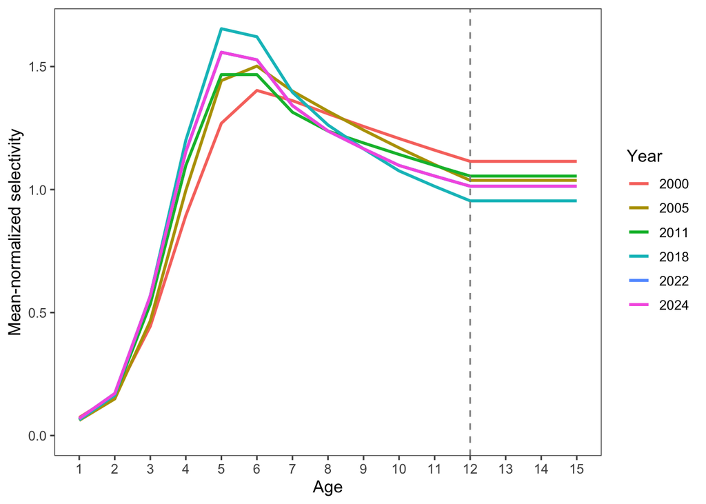

Figure 1: Simulated fishery selectivity from the RTMB age-coefficient plus change-year deviation form.

```r
fishery_df <- as_tibble(sel_fishery, rownames = "year") |>
  mutate(year = as.integer(year)) |>
  pivot_longer(-year, names_to = "age", values_to = "selectivity") |>
  mutate(age = as.integer(age))

ggplot(fishery_df |> filter(year %in% c(2000, 2005, 2011, 2018, 2022, 2024)),
       aes(x = age, y = selectivity, color = factor(year))) +
  geom_line(linewidth = 1) +
  geom_vline(xintercept = fishery_nsel, linetype = "dashed", color = "gray55") +
  scale_x_continuous(breaks = ages) +
  scale_y_continuous(limits = c(0, NA)) +
  labs(x = "Age", y = "Mean-normalized selectivity", color = "Year")
```

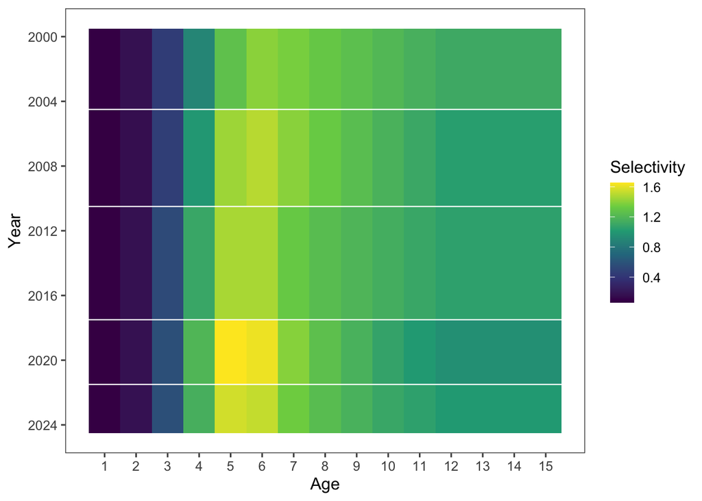

Figure 2: Time-varying fishery selectivity surface from simulated change-year deviations.

```r
ggplot(fishery_df, aes(x = age, y = year, fill = selectivity)) +
  geom_tile() +
  geom_hline(yintercept = fishery_change_years + 0.5, color = "white", linewidth = 0.4) +
  scale_x_continuous(breaks = ages) +
  scale_y_reverse(breaks = seq(2000, 2024, by = 4)) +
  scale_fill_viridis_c(name = "Selectivity") +
  labs(x = "Age", y = "Year")
```

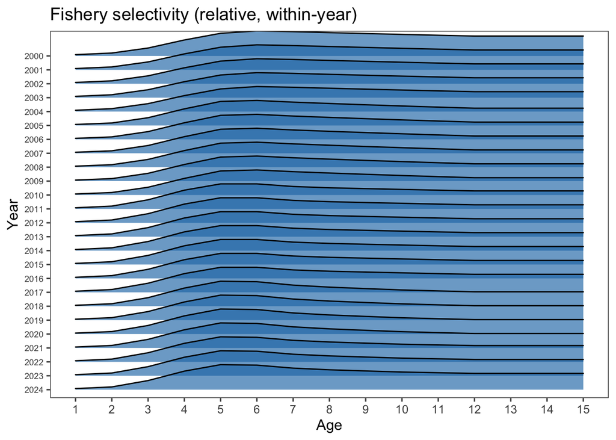

Figure 3: Fishery selectivity through time shown as ggridges (normalized within year).

```r
fishery_ridge_df <- fishery_df |>
  group_by(year) |>
  mutate(relative_selectivity = selectivity / max(selectivity, na.rm = TRUE)) |>
  ungroup() |>
  mutate(year_factor = factor(year, levels = rev(sort(unique(year)))))

ggplot(fishery_ridge_df, aes(x = age, y = year_factor, height = relative_selectivity, group = year_factor)) +
  geom_density_ridges(stat = "identity", fill = "#1f78b4", alpha = 0.65, rel_min_height = 0.01) +
  scale_x_continuous(breaks = ages) +
  labs(x = "Age", y = "Year", title = "Fishery selectivity (relative, within-year)") +
  theme(axis.text.y = element_text(size = 7))
```

The fishery penalty is defined in `selectivity_like_fsh()`. It combines:

$$P_{\mathrm{shape}} =
\lambda_{\mathrm{dome}}
\sum_y \sum_{a=6}^{A_{\mathrm{sel}}-1}
\left(\ell_{y,a} - \ell_{y,a+1}\right)^2,$$

$$P_{\mathrm{dev}} =
\|\boldsymbol{\delta}\|^2
+ \frac{\lambda_C}{K}\left\|\Delta_a^2 \ell_{1,\cdot}\right\|^2
+ \sum_{k=1}^{K}
\left[
\frac{\lambda_C}{K}\left\|\Delta_a^2 \ell_{y_k,\cdot}\right\|^2
+ \frac{\left\|\ell_{y_k-1,\cdot} - \ell_{y_k,\cdot}\right\|^2}
{2\sigma_k^2}
\right].$$

In `R/Rpm.R`, `sel_ch_sig_fsh` is set to 0.5 for most fishery change years, with larger values for two late-period changes.

```r
norm2 <- function(x) sum(x^2, na.rm = TRUE)
second_difference <- function(x) diff(x, differences = 2)

fishery_penalty <- function(log_sel_fsh, n_selages_fsh, yrs_ch_fsh, sel_devs_fsh,
                            domFish = 3, selCFsh = 1, sel_ch_sig_fsh = NULL) {
  years <- as.integer(rownames(log_sel_fsh))
  nyrs <- nrow(log_sel_fsh)
  nch <- length(yrs_ch_fsh)
  if (is.null(sel_ch_sig_fsh)) sel_ch_sig_fsh <- rep(0.5, nch)

  year_index <- setNames(seq_along(years), as.character(years))

  # shape penalty
  shape_pen <- 0
  for (i in seq_len(nyrs)) {
    for (j in 6:(n_selages_fsh - 1)) {
      d <- log_sel_fsh[i, j] - log_sel_fsh[i, j + 1]
      shape_pen <- shape_pen + domFish * d * d
    }
  }

  # dev penalty
  dev_pen <- norm2(sel_devs_fsh)
  dev_pen <- dev_pen + selCFsh / nch * norm2(second_difference(log_sel_fsh[1, ]))

  for (k in seq_len(nch)) {
    yy <- yrs_ch_fsh[k]
    ik <- unname(year_index[as.character(yy)])
    ip <- unname(year_index[as.character(yy - 1)])
    if (is.na(ik) || is.na(ip)) next

    dev_pen <- dev_pen + selCFsh / nch * norm2(second_difference(log_sel_fsh[ik, ]))
    sigma <- sel_ch_sig_fsh[k]
    dev_pen <- dev_pen + norm2(log_sel_fsh[ip, ] - log_sel_fsh[ik, ]) / (2 * sigma^2)
  }

  tibble(shape = shape_pen, dev = dev_pen, total = shape_pen + dev_pen)
}

# Build three fishery scenarios using the same baseline coefficients.
make_fishery_scenario <- function(label, change_years) {
  if (length(change_years) == 0) {
    devs <- matrix(0, nrow = 0, ncol = fishery_nsel)
  } else {
    # reuse the same deviation rows cyclically for comparability
    idx <- rep(seq_len(nrow(fishery_devs)), length.out = length(change_years))
    devs <- fishery_devs[idx, , drop = FALSE]
  }

  sel <- compute_fishery_demo(
    nsel = fishery_nsel,
    years = fishery_years,
    nages = length(ages),
    coffs = fishery_coffs,
    sel_devs = devs,
    yrs_ch_fsh = change_years
  )

  log_sel <- log(sel)
  rownames(log_sel) <- fishery_years

  penalty <- fishery_penalty(
    log_sel_fsh = log_sel,
    n_selages_fsh = fishery_nsel,
    yrs_ch_fsh = change_years,
    sel_devs_fsh = devs,
    domFish = 3,
    selCFsh = 1,
    sel_ch_sig_fsh = rep(0.5, length(change_years))
  )

  penalty |>
    mutate(
      scenario = label,
      n_change_years = length(change_years)
    )
}

fishery_like_tbl <- bind_rows(
  make_fishery_scenario("No time-variation (carry-forward)", integer(0)),
  make_fishery_scenario("Few change years", fishery_change_years),
  make_fishery_scenario("Change every year (max flexibility)", fishery_years[-length(fishery_years)])
) |>
  select(scenario, n_change_years, shape, dev, total)

fishery_like_tbl |>
  mutate(across(c(shape, dev, total), ~round(.x, 3))) |>
  gt_report() |>
  tab_header(title = "Fishery selectivity penalties")
```

Table 3: Fishery selectivity penalty components under alternative time-variation scenarios (simulated).

Fishery selectivity penalties

| scenario | n_change_years | shape | dev | total |
| --- | --- | --- | --- | --- |
| No time-variation (carry-forward) | 0 | 0.668 | Inf | Inf |
| Few change years | 4 | 1.943 | 0.837 | 2.781 |
| Change every year (max flexibility) | 24 | 16.656 | 7.053 | 23.709 |

# 5 BTS Logistic Form

The BTS selectivity form is annual logistic selectivity for ages 2 and older, with age 1 overwritten by a separate estimated annual term. `R/Rpm.R` computes

$$\log s_{t,a}^{\mathrm{BTS}} =
-\log\left[
1 + \exp\left\{-\exp(\gamma_t)
\left(x_a - \exp(\alpha_t)\right)\right\}
\right],$$

$$\log s_{t,1}^{\mathrm{BTS}} = \eta_t,$$

```r
compute_bts_demo <- function(years, ages, log_slope, log_a50, log_age1) {
  age_vector <- ages + 0.5
  log_sel <- matrix(0, nrow = length(years), ncol = length(ages),
                    dimnames = list(years, ages))
  for (i in seq_along(years)) {
    log_sel[i, ] <- -log(1 + exp(-exp(log_slope[i]) * (age_vector - exp(log_a50[i]))))
  }
  log_sel[, 1] <- log_age1
  exp(log_sel)
}

bts_years <- 2000:2024
t_index <- seq_along(bts_years)
bts_log_slope <- log(1.25) + 0.18 * sin(t_index / 4)
bts_log_a50 <- log(4.8) + 0.10 * cos(t_index / 5)
bts_log_age1 <- log(0.08) + 0.25 * sin(t_index / 3)

sel_bts <- compute_bts_demo(
  years = bts_years,
  ages = ages,
  log_slope = bts_log_slope,
  log_a50 = bts_log_a50,
  log_age1 = bts_log_age1
)
```

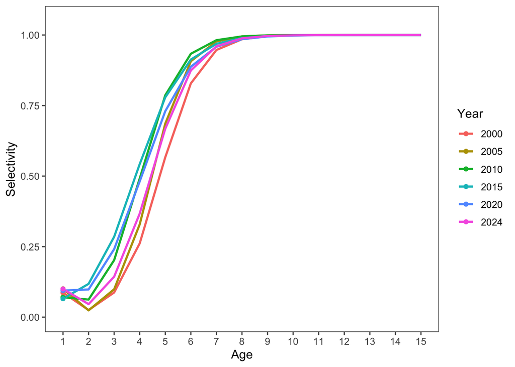

Figure 4: Simulated BTS annual logistic selectivity with a separate age-1 effect.

```r
bts_df <- as_tibble(sel_bts, rownames = "year") |>
  mutate(year = as.integer(year)) |>
  pivot_longer(-year, names_to = "age", values_to = "selectivity") |>
  mutate(age = as.integer(age))

ggplot(bts_df |> filter(year %in% c(2000, 2005, 2010, 2015, 2020, 2024)),
       aes(x = age, y = selectivity, color = factor(year))) +
  geom_line(linewidth = 1) +
  geom_point(data = bts_df |> filter(age == 1, year %in% c(2000, 2005, 2010, 2015, 2020, 2024)),
             size = 1.6) +
  scale_x_continuous(breaks = ages) +
  scale_y_continuous(limits = c(0, 1.05)) +
  labs(x = "Age", y = "Selectivity", color = "Year")
```

The active BTS regularization in `selectivity_like_bts()` is applied to first differences in the implied log-selectivity surface:

$$P_{\mathrm{BTS,time}} =
\lambda_{\mathrm{BTS}}
\sum_{a=q_{\min}}^{q_{\max}-1}
\left\|\Delta_t \tilde{\ell}_{\cdot,a}\right\|^2,$$

$$P_{\mathrm{BTS,age1}} =
8 \left\|\Delta_t(\eta_t - \bar{\eta})\right\|^2.$$

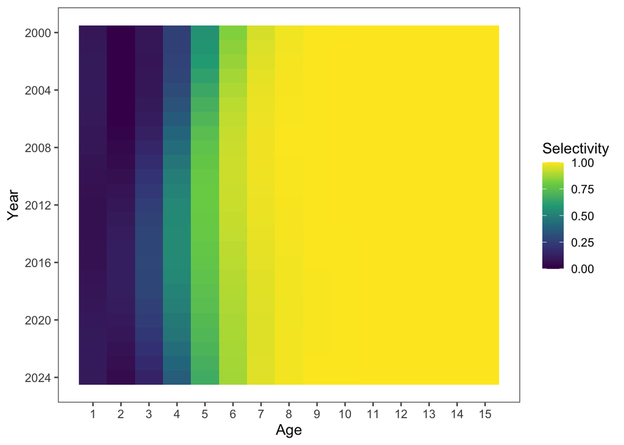

Figure 5: Simulated BTS selectivity surface under annual slope, age-at-50, and age-1 variation.

```r
ggplot(bts_df, aes(x = age, y = year, fill = selectivity)) +
  geom_tile() +
  scale_x_continuous(breaks = ages) +
  scale_y_reverse(breaks = seq(2000, 2024, by = 4)) +
  scale_fill_viridis_c(name = "Selectivity", limits = c(0, 1)) +
  labs(x = "Age", y = "Year")
```

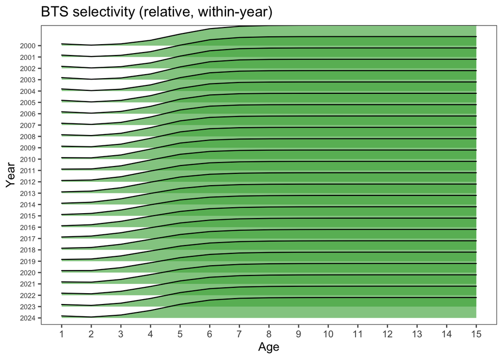

Figure 6: BTS selectivity through time shown as ggridges (normalized within year).

```r
bts_ridge_df <- bts_df |>
  group_by(year) |>
  mutate(relative_selectivity = selectivity / max(selectivity, na.rm = TRUE)) |>
  ungroup() |>
  mutate(year_factor = factor(year, levels = rev(sort(unique(year)))))

ggplot(bts_ridge_df, aes(x = age, y = year_factor, height = relative_selectivity, group = year_factor)) +
  geom_density_ridges(stat = "identity", fill = "#4daf4a", alpha = 0.65, rel_min_height = 0.01) +
  scale_x_continuous(breaks = ages) +
  labs(x = "Age", y = "Year", title = "BTS selectivity (relative, within-year)") +
  theme(axis.text.y = element_text(size = 7))
```

# 6 ATS Age-Coefficient Form

The ATS form is similar to the fishery coefficient form, but it begins at `mina_ats` and uses ATS-specific change years and penalties. In `compute_selectivity_ats_devs()`,

$$\ell_{1,a} =
\begin{cases}
0, & a < a_{\min}^{\mathrm{ATS}} \\
c_a, & a_{\min}^{\mathrm{ATS}} \le a \le A_{\mathrm{sel}}^{\mathrm{ATS}} \\
c_{A_{\mathrm{sel}}^{\mathrm{ATS}}}, & a > A_{\mathrm{sel}}^{\mathrm{ATS}}.
\end{cases}$$

Change-year deviations are added to the modeled age range, the terminal age is extended, and each annual curve is mean-normalized.

```r
compute_ats_demo <- function(nsel, nages, years, mina_ats, coffs, sel_devs, yrs_ch_ats) {
  log_sel <- matrix(0, nrow = length(years), ncol = nages,
                    dimnames = list(years, seq_len(nages)))
  log_sel[1, mina_ats:nsel] <- coffs
  log_sel[1, (nsel + 1):nages] <- log_sel[1, nsel]
  log_sel[1, ] <- mean_normalize(log_sel[1, ])

  ii <- 1
  for (i in seq_len(length(years) - 1)) {
    yr_next <- years[i + 1]
    if (ii <= length(yrs_ch_ats) && yr_next == yrs_ch_ats[ii]) {
      log_sel[i + 1, mina_ats:nsel] <- log_sel[i, mina_ats:nsel] + sel_devs[ii, ]
      log_sel[i + 1, (nsel + 1):nages] <- log_sel[i + 1, nsel]
      ii <- ii + 1
    } else {
      log_sel[i + 1, ] <- log_sel[i, ]
    }
    log_sel[i + 1, ] <- mean_normalize(log_sel[i + 1, ])
  }

  exp(log_sel)
}

ats_years <- 2000:2024
ats_mina <- 2
ats_nsel <- 12
ats_coffs <- c(-1.0, -0.30, 0.20, 0.36, 0.28, 0.08, -0.16, -0.42, -0.65, -0.82, -0.95)
ats_change_years <- c(2006, 2013, 2019, 2023)
ats_devs <- rbind(
  c(0.04, 0.06, 0.04, 0.00, -0.03, -0.05, -0.06, -0.06, -0.04, -0.02, 0.00),
  c(-0.05, -0.02, 0.03, 0.06, 0.05, 0.02, -0.02, -0.05, -0.08, -0.08, -0.08),
  c(0.02, 0.04, 0.06, 0.04, 0.00, -0.04, -0.06, -0.08, -0.08, -0.06, -0.04),
  c(-0.03, -0.01, 0.02, 0.04, 0.04, 0.01, -0.02, -0.04, -0.04, -0.02, 0.00)
)

sel_ats <- compute_ats_demo(
  nsel = ats_nsel,
  nages = length(ages),
  years = ats_years,
  mina_ats = ats_mina,
  coffs = ats_coffs,
  sel_devs = ats_devs,
  yrs_ch_ats = ats_change_years
)
```

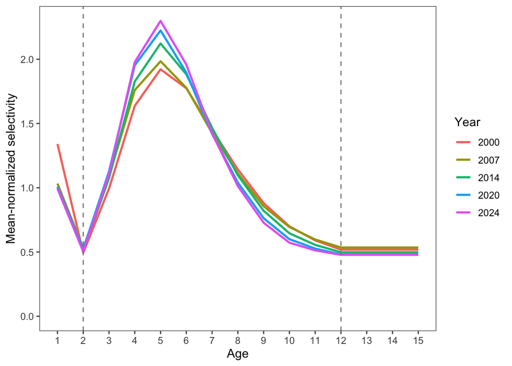

Figure 7: Simulated ATS selectivity from the RTMB coefficient plus change-year deviation form.

```r
ats_df <- as_tibble(sel_ats, rownames = "year") |>
  mutate(year = as.integer(year)) |>
  pivot_longer(-year, names_to = "age", values_to = "selectivity") |>
  mutate(age = as.integer(age))

ggplot(ats_df |> filter(year %in% c(2000, 2007, 2014, 2020, 2024)),
       aes(x = age, y = selectivity, color = factor(year))) +
  geom_line(linewidth = 1) +
  geom_vline(xintercept = c(ats_mina, ats_nsel), linetype = "dashed", color = "gray55") +
  scale_x_continuous(breaks = ages) +
  scale_y_continuous(limits = c(0, NA)) +
  labs(x = "Age", y = "Mean-normalized selectivity", color = "Year")
```

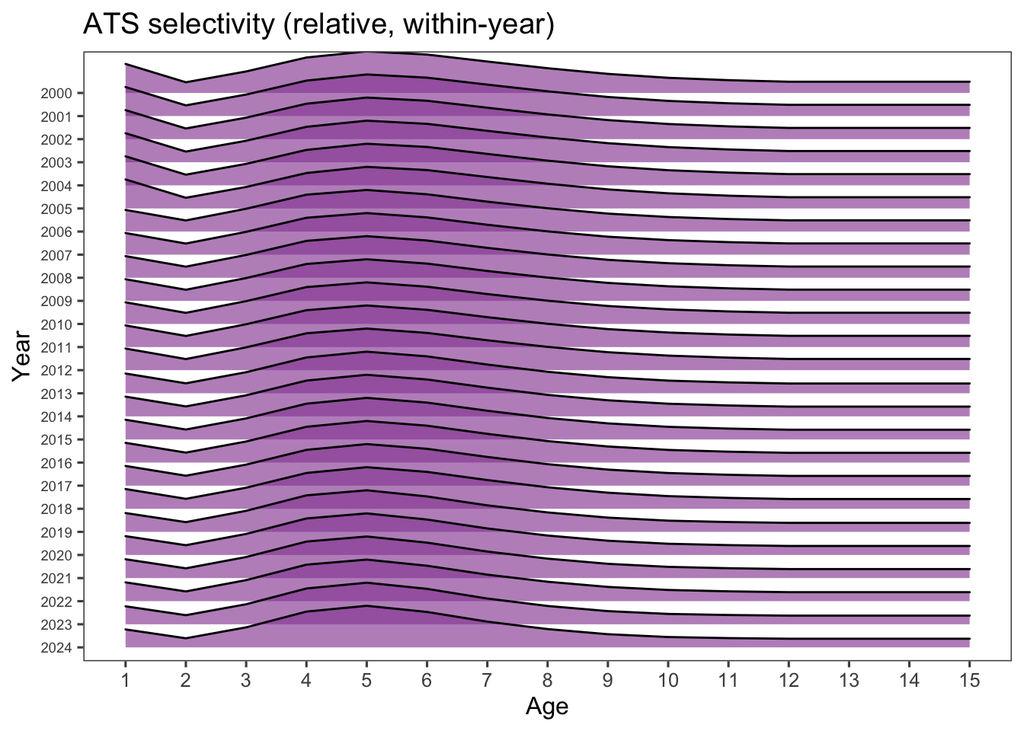

Figure 8: ATS selectivity through time shown as ggridges (normalized within year).

```r
ats_ridge_df <- ats_df |>
  group_by(year) |>
  mutate(relative_selectivity = selectivity / max(selectivity, na.rm = TRUE)) |>
  ungroup() |>
  mutate(year_factor = factor(year, levels = rev(sort(unique(year)))))

ggplot(ats_ridge_df, aes(x = age, y = year_factor, height = relative_selectivity, group = year_factor)) +
  geom_density_ridges(stat = "identity", fill = "#984ea3", alpha = 0.65, rel_min_height = 0.01) +
  scale_x_continuous(breaks = ages) +
  labs(x = "Age", y = "Year", title = "ATS selectivity (relative, within-year)") +
  theme(axis.text.y = element_text(size = 7))
```

The ATS penalty in `selectivity_like_ats()` combines a shape penalty over older ages, curvature penalties at change years, and a random-walk penalty between the change year and the preceding year:

$$P_{\mathrm{ATS,RW}} =
\sum_{k=1}^{K}
\frac{\left\|\ell_{y_k-1,\cdot} - \ell_{y_k,\cdot}\right\|^2}
{2\sigma_k^2}.$$

In `R/Rpm.R`, `sel_ch_sig_ats` is set to 0.138 for each ATS change year.

```r
ats_penalty <- function(log_sel_ats, n_selages_ats, yrs_ch_ats, sel_ch_sig_ats,
                        selATS = 1, selTATS = 1) {
  years <- as.integer(rownames(log_sel_ats))
  year_index <- setNames(seq_along(years), as.character(years))

  # shape penalty
  shape_pen <- 0
  for (yy in years) {
    i <- unname(year_index[as.character(yy)])
    for (j in 5:(n_selages_ats - 1)) {
      d <- log_sel_ats[i, j] - log_sel_ats[i, j + 1]
      shape_pen <- shape_pen + selATS * d * d
    }
  }

  # curvature + RW
  curv <- 0
  rw <- 0
  for (k in seq_along(yrs_ch_ats)) {
    yy <- yrs_ch_ats[k]
    ik <- unname(year_index[as.character(yy)])
    ip <- unname(year_index[as.character(yy - 1)])
    if (is.na(ik) || is.na(ip)) next

    curv <- curv + selTATS * norm2(second_difference(log_sel_ats[ik, ]))
    sigma <- sel_ch_sig_ats[k]
    rw <- rw + norm2(log_sel_ats[ip, ] - log_sel_ats[ik, ]) / (2 * sigma^2)
  }

  tibble(shape = shape_pen, curvature = curv, random_walk = rw, total = shape_pen + curv + rw)
}

make_ats_scenario <- function(label, change_years) {
  if (length(change_years) == 0) {
    devs <- matrix(0, nrow = 0, ncol = length(ats_coffs))
  } else {
    idx <- rep(seq_len(nrow(ats_devs)), length.out = length(change_years))
    devs <- ats_devs[idx, , drop = FALSE]
  }

  sel <- compute_ats_demo(
    nsel = ats_nsel,
    nages = length(ages),
    years = ats_years,
    mina_ats = ats_mina,
    coffs = ats_coffs,
    sel_devs = devs,
    yrs_ch_ats = change_years
  )

  log_sel <- log(sel)
  rownames(log_sel) <- ats_years

  pen <- ats_penalty(
    log_sel_ats = log_sel,
    n_selages_ats = ats_nsel,
    yrs_ch_ats = change_years,
    sel_ch_sig_ats = rep(0.138, length(change_years)),
    selATS = 1,
    selTATS = 1
  )

  pen |>
    mutate(scenario = label, n_change_years = length(change_years))
}

ats_like_tbl <- bind_rows(
  make_ats_scenario("No time-variation (carry-forward)", integer(0)),
  make_ats_scenario("Few change years", ats_change_years),
  make_ats_scenario("Change every year (max flexibility)", ats_years[-length(ats_years)])
) |>
  select(scenario, n_change_years, shape, curvature, random_walk, total)

ats_like_tbl |>
  mutate(across(c(shape, curvature, random_walk, total), ~round(.x, 3))) |>
  gt_report() |>
  tab_header(title = "ATS selectivity penalties")
```

Table 4: ATS selectivity penalty components under alternative time-variation scenarios (simulated).

ATS selectivity penalties

| scenario | n_change_years | shape | curvature | random_walk | total |
| --- | --- | --- | --- | --- | --- |
| No time-variation (carry-forward) | 0 | 6.758 | 0.00 | 0.000 | 6.758 |
| Few change years | 4 | 7.923 | 9.50 | 4.784 | 22.207 |
| Change every year (max flexibility) | 24 | 6.758 | 72.28 | 0.000 | 79.037 |

# 7 Comparison to `selex` Forms

The RTMB coefficient forms are closest to the nonparametric, mean-normalized selectivity construction in `selex/R/selectivity.R`, but they use deterministic change-year random-walk penalties rather than the separable 2D AR1 prior shown in `selex/timevarying_selectivity.qmd`.

$$s(a) = \frac{1}{1 + \exp\left[-\log(19)\frac{a-a_{50}}{\delta}\right]}.$$

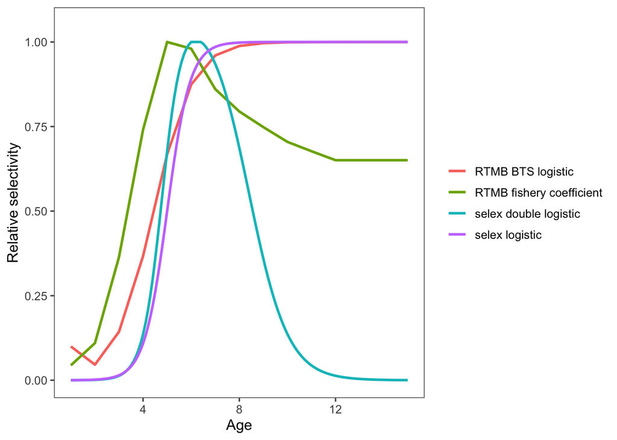

Figure 9: Generic selex forms compared with RTMB-style coefficient and BTS logistic examples.

```r
logistic_sel <- function(age, a50, delta) {
  1 / (1 + exp(-log(19) * (age - a50) / delta))
}

dbl_logistic_sel <- function(age, p1, p2, p3) {
  gamma1 <- p1 + p2
  gamma2 <- 2 * p1 + p2 + p3
  asc <- 1 / (1 + exp(-log(19) * (age - gamma1) / p1))
  desc <- 1 - 1 / (1 + exp(-log(19) * (age - gamma2) / p3))
  pmin(asc * desc * 0.95^(-2), 1)
}

compare_df <- bind_rows(
  tibble(form = "selex logistic", age = plot_ages,
         selectivity = logistic_sel(plot_ages, a50 = 5, delta = 1.4)),
  tibble(form = "selex double logistic", age = plot_ages,
         selectivity = dbl_logistic_sel(plot_ages, p1 = 1.2, p2 = 3.6, p3 = 2.4)),
  fishery_df |>
    filter(year == 2024) |>
    transmute(form = "RTMB fishery coefficient", age = as.numeric(age),
              selectivity = selectivity / max(selectivity)),
  bts_df |>
    filter(year == 2024) |>
    transmute(form = "RTMB BTS logistic", age = as.numeric(age),
              selectivity = selectivity)
)

ggplot(compare_df, aes(x = age, y = selectivity, color = form)) +
  geom_line(linewidth = 1) +
  scale_y_continuous(limits = c(0, 1.05)) +
  labs(x = "Age", y = "Relative selectivity", color = NULL)
```

# 8 Takeaways

The current RTMB model implements selectivity as fleet-specific code paths rather than as a selectable family of forms.

- Fishery selectivity is a flexible age-coefficient curve with annual change-year deviations, mean normalization, terminal-age extension, and curvature/random-walk/shape penalties.
- BTS selectivity is the only active parametric logistic form: annual slope and age-at-50 parameters define ages 2+, and age 1 has its own annual parameter.
- ATS selectivity is another flexible age-coefficient curve, starting at `mina_ats`, with change-year deviations and ATS-specific penalties.
- The `selex` repository documents additional candidate forms: double logistic, Richards, splines, and separable 2D AR1 time variation. Those are useful reference implementations, but they are not currently wired as selectable alternatives inside `rtmb_ebswp`.